# Portfolio RAKFIN

Ashley

06 September, 2019

[figure not shown]

This file contains the details of the following models

| ModelList | ModelType |
| --- | --- |
| DR_logit_FD ~ avg_oil_pri_barr | Champion |
| DR_logit_FD ~ rl_est_ad_yoy+uae_rl_cons | Challenger 1 |
| DR_logit_FD ~ eibor+eibor_yoy | Challenger 2 |
| DR_logit_FD ~ DR_logit_FD_lag1 + uae_ann_imp_yoy + rl_est_ad_log + uae_rl_cons_3qma | Challenger 3 |
| DR_logit_FD ~ uae_rl_cons+rl_est_ad_yoy.1 | Challenger 4 |

## Champion Model

### Summary Regression Results

Summary Results for `DR_logit_FD ~ avg_oil_pri_barr`

| var | Estimates | VIF | p | se | t | DirectionCheck | Significance | Multicollinearity |
| --- | --- | --- | --- | --- | --- | --- | --- | --- |
| (Intercept) | 0.157427 | NA | 2.1e-05 | 0.030875 | 5.098930 | NA | NA | NA |
| avg_oil_pri_barr | -0.001557 | NA | 0.000168 | 0.000359 | -4.340063 | PASS | PASS | NA |

| R2 | 0.402171 |
| --- | --- |
| adjR2 | 0.380820 |
| MAPE_test | 7.032908 |

### Diagnostic Tests

Tests for stationarity for `DR_logit_FD ~ avg_oil_pri_barr`

| Check | Test | statistic | pvalue | Criteria | results | FINAL |
| --- | --- | --- | --- | --- | --- | --- |
| Heteroskedasticity | Breusch-Pagan Test | 2.323277 | 0.127451 | p > 0.1 | Homoskedasticity | PASS |
| Stationarity-KPSS | KPSS | 0.053001 | 0.1 | p > 0.1 | Stationary | PASS |
| Unit Root | ADF Test | -3.491948 | 0.063016 | p < 0.1 | Stationary | PASS |
| Auto-Correlation | Durbin Watson Test | 1.39399 | 0.076 | p > 0.1 | Auto-Correlation | FAIL |
| Normality | Shapiro-Wilk Test | 0.969833 | 0.534607 | p > 0.1 | Residuals Normally distributed | PASS |

### Forecast

Observed versus Predicted Values for `DR_logit_FD ~ avg_oil_pri_barr`

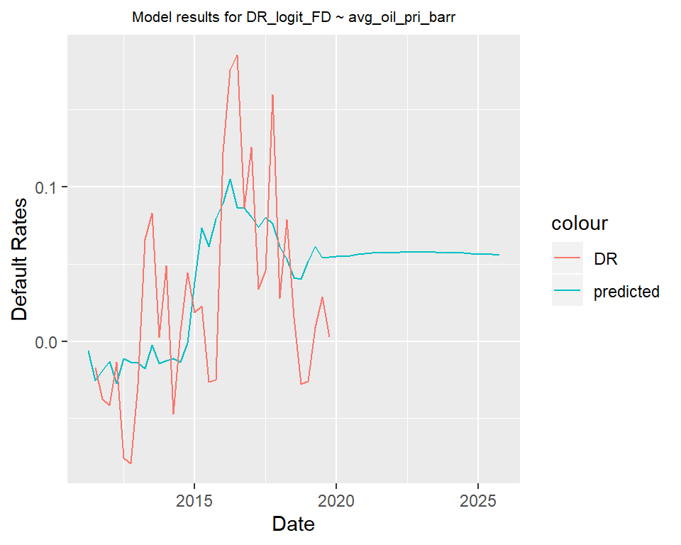

| Date | 31/03/2011 | 30/06/2011 | 30/09/2011 | 31/12/2011 | 31/03/2012 | 30/06/2012 | 30/09/2012 | 31/12/2012 | 31/03/2013 | 30/06/2013 | 30/09/2013 | 31/12/2013 | 31/03/2014 | 30/06/2014 | 30/09/2014 | 31/12/2014 | 31/03/2015 | 30/06/2015 | 30/09/2015 | 31/12/2015 | 31/03/2016 | 30/06/2016 | 30/09/2016 | 31/12/2016 | 31/03/2017 | 30/06/2017 | 30/09/2017 | 31/12/2017 | 31/03/2018 | … |
| --- | --- | --- | --- | --- | --- | --- | --- | --- | --- | --- | --- | --- | --- | --- | --- | --- | --- | --- | --- | --- | --- | --- | --- | --- | --- | --- | --- | --- | --- | --- |
| DR_logit_FD | NA | -0.017286838 | -0.037230734 | -0.041564062 | -0.013549855 | -0.075622008 | -0.079106486 | -0.028395601 | 0.066021917 | 0.082829421 | 0.002488125 | 0.049015182 | -0.047017433 | 0.006364493 | 0.044344414 | 0.018512448 | 0.022610400 | -0.026556347 | -0.024788142 | 0.122798689 | 0.176115301 | 0.185365543 | 0.086454050 | 0.125908108 | 0.033992077 | 0.045653546 | 0.159748619 | 0.027748153 | 0.078890223 | … |
| avg_oil_pri_barr | 104.96000 | 117.36000 | 113.34000 | 109.39667 | 118.49000 | 108.41667 | 109.61333 | 110.08667 | 112.49333 | 102.57667 | 110.27000 | 109.21000 | 108.16667 | 109.70000 | 101.82333 | 76.40333 | 53.91667 | 61.69333 | 50.23333 | 43.57000 | 33.69667 | 45.52333 | 45.78667 | 49.18667 | 53.68000 | 49.67000 | 52.11000 | 61.53000 | 66.80667 | … |
| predicted_values | -0.006031773 | -0.025342831 | -0.019082311 | -0.012941187 | -0.027102629 | -0.011414990 | -0.013278611 | -0.014015753 | -0.017763760 | -0.002320105 | -0.014301266 | -0.012650482 | -0.011025654 | -0.013413581 | -0.001146906 | 0.038440763 | 0.073460225 | 0.061349285 | 0.079196440 | 0.089573538 | 0.104949709 | 0.086531527 | 0.086121427 | 0.080826459 | 0.073828796 | 0.080073743 | 0.076273826 | 0.061603651 | 0.053386069 | … |

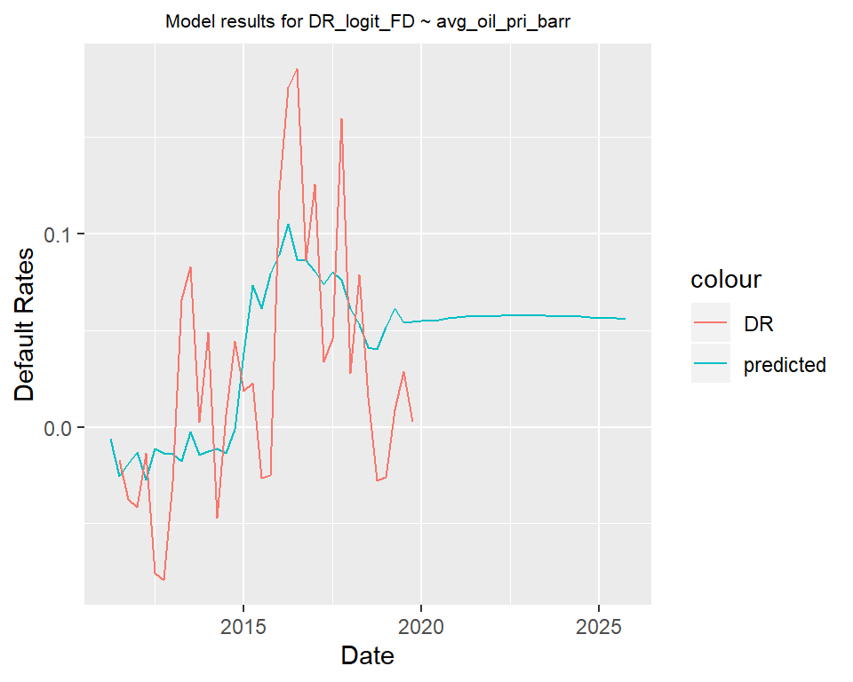

## Challenger Model 1

### Summary Regression Results

Summary Results for `DR_logit_FD ~ rl_est_ad_yoy+uae_rl_cons`

| var | Estimates | VIF | p | se | t | DirectionCheck | Significance | Multicollinearity |
| --- | --- | --- | --- | --- | --- | --- | --- | --- |
| (Intercept) | 0.661418 | NA | 0.005278 | 0.217960 | 3.034592 | NA | NA | NA |
| rl_est_ad_yoy | 0.318425 | 2.008192 | 0.049516 | 0.154838 | 2.056510 | FAIL | PASS | PASS |
| uae_rl_cons | -0.005526 | 2.008192 | 0.007395 | 0.001908 | -2.896397 | PASS | PASS | PASS |

| R2 | 0.237054 |
| --- | --- |
| adjR2 | 0.180540 |
| MAPE_test | 1.250057 |

### Diagnostic Tests

Tests for stationarity for `DR_logit_FD ~ rl_est_ad_yoy+uae_rl_cons`

| Check | Test | statistic | pvalue | Criteria | results | FINAL |
| --- | --- | --- | --- | --- | --- | --- |
| Heteroskedasticity | Breusch-Pagan Test | 4.36699 | 0.112647 | p > 0.1 | Homoskedasticity | PASS |
| Stationarity-KPSS | KPSS | 0.228637 | 0.1 | p > 0.1 | Stationary | PASS |
| Unit Root | ADF Test | -4.210308 | 0.014778 | p < 0.1 | Stationary | PASS |
| Auto-Correlation | Durbin Watson Test | 1.157192 | 0.006 | p > 0.1 | Auto-Correlation | FAIL |
| Normality | Shapiro-Wilk Test | 0.965108 | 0.41527 | p > 0.1 | Residuals Normally distributed | PASS |

### Forecast

Observed versus Predicted Values for `DR_logit_FD ~ rl_est_ad_yoy+uae_rl_cons`

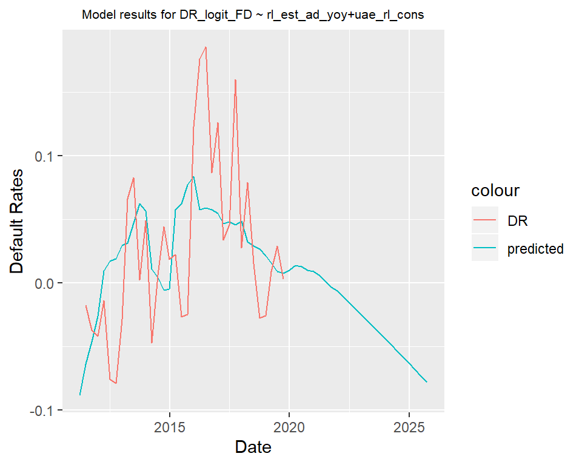

| Date | 31/03/2011 | 30/06/2011 | 30/09/2011 | 31/12/2011 | 31/03/2012 | 30/06/2012 | 30/09/2012 | 31/12/2012 | 31/03/2013 | 30/06/2013 | 30/09/2013 | 31/12/2013 | 31/03/2014 | 30/06/2014 | 30/09/2014 | 31/12/2014 | 31/03/2015 | 30/06/2015 | 30/09/2015 | 31/12/2015 | 31/03/2016 | 30/06/2016 | 30/09/2016 | 31/12/2016 | 31/03/2017 | 30/06/2017 | 30/09/2017 | 31/12/2017 | 31/03/2018 | … |
| --- | --- | --- | --- | --- | --- | --- | --- | --- | --- | --- | --- | --- | --- | --- | --- | --- | --- | --- | --- | --- | --- | --- | --- | --- | --- | --- | --- | --- | --- | --- |
| DR_logit_FD | NA | -0.017286838 | -0.037230734 | -0.041564062 | -0.013549855 | -0.075622008 | -0.079106486 | -0.028395601 | 0.066021917 | 0.082829421 | 0.002488125 | 0.049015182 | -0.047017433 | 0.006364493 | 0.044344414 | 0.018512448 | 0.022610400 | -0.026556347 | -0.024788142 | 0.122798689 | 0.176115301 | 0.185365543 | 0.086454050 | 0.125908108 | 0.033992077 | 0.045653546 | 0.159748619 | 0.027748153 | 0.078890223 | … |
| rl_est_ad_yoy | -0.134305525 | -0.086858327 | -0.072159828 | -0.058779910 | -0.081005587 | -0.095120319 | -0.105668570 | -0.067298952 | -0.007319645 | 0.075824812 | 0.167669848 | 0.203274747 | 0.251921515 | 0.251883070 | 0.196280580 | 0.134105513 | 0.041004268 | -0.023374639 | -0.028020474 | -0.028734674 | -0.022223820 | -0.014472912 | -0.017806407 | -0.028555321 | -0.060316293 | -0.065525017 | -0.085800314 | -0.093929590 | -0.077501963 | … |
| uae_rl_cons | 127.9276 | 126.1714 | 123.8767 | 121.0434 | 113.3123 | 111.1456 | 110.1842 | 110.4279 | 113.5419 | 115.5300 | 118.0573 | 121.1238 | 132.2503 | 133.3867 | 132.0540 | 128.2520 | 111.6168 | 107.0220 | 104.1036 | 102.8616 | 107.9799 | 108.2171 | 108.2571 | 108.0999 | 107.7454 | 107.1938 | 106.4449 | 105.4989 | 109.3616 | … |
| predicted_values | -0.088229619 | -0.063417265 | -0.046057101 | -0.026140990 | 0.009501349 | 0.016978856 | 0.018932587 | 0.029803561 | 0.031695760 | 0.047185463 | 0.062466378 | 0.056859751 | 0.010868711 | 0.004577009 | -0.005763747 | -0.004553448 | 0.057720771 | 0.062610110 | 0.077256825 | 0.083892339 | 0.057683341 | 0.058840898 | 0.057558577 | 0.055004673 | 0.046849677 | 0.048239257 | 0.045920936 | 0.048559886 | 0.032446891 | … |

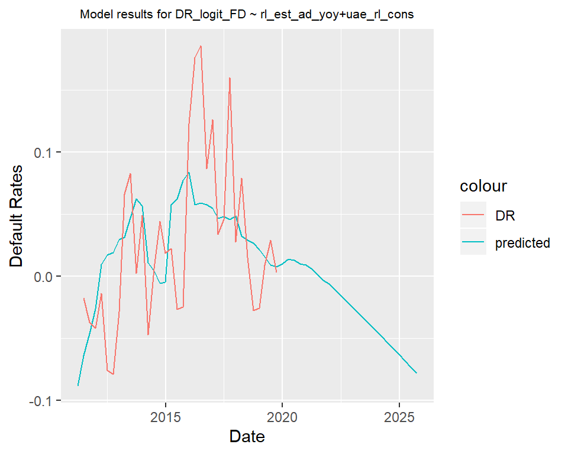

## Challenger Model 2

### Summary Regression Results

Summary Results for `DR_logit_FD ~ eibor+eibor_yoy`

| var | Estimates | VIF | p | se | t | DirectionCheck | Significance | Multicollinearity |
| --- | --- | --- | --- | --- | --- | --- | --- | --- |
| (Intercept) | 0.114696 | NA | 0.000891 | 0.030717 | 3.733891 | NA | NA | NA |
| eibor | -7.133710 | 1.299543 | 0.005012 | 2.334701 | -3.055514 | PASS | PASS | PASS |
| eibor_yoy | 0.155697 | 1.299543 | 6.9e-05 | 0.033144 | 4.697533 | FAIL | PASS | PASS |

| R2 | 0.458907 |
| --- | --- |
| adjR2 | 0.418826 |
| MAPE_test | 8.760275 |

### Diagnostic Tests

Tests for stationarity for `DR_logit_FD ~ eibor+eibor_yoy`

| Check | Test | statistic | pvalue | Criteria | results | FINAL |
| --- | --- | --- | --- | --- | --- | --- |
| Heteroskedasticity | Breusch-Pagan Test | 0.79426 | 0.672247 | p > 0.1 | Homoskedasticity | PASS |
| Stationarity-KPSS | KPSS | 0.047955 | 0.1 | p > 0.1 | Stationary | PASS |
| Unit Root | ADF Test | -3.903155 | 0.02667 | p < 0.1 | Stationary | PASS |
| Auto-Correlation | Durbin Watson Test | 1.477761 | 0.062 | p > 0.1 | Auto-Correlation | FAIL |
| Normality | Shapiro-Wilk Test | 0.985532 | 0.945891 | p > 0.1 | Residuals Normally distributed | PASS |

### Forecast

Observed versus Predicted Values for `DR_logit_FD ~ eibor+eibor_yoy`

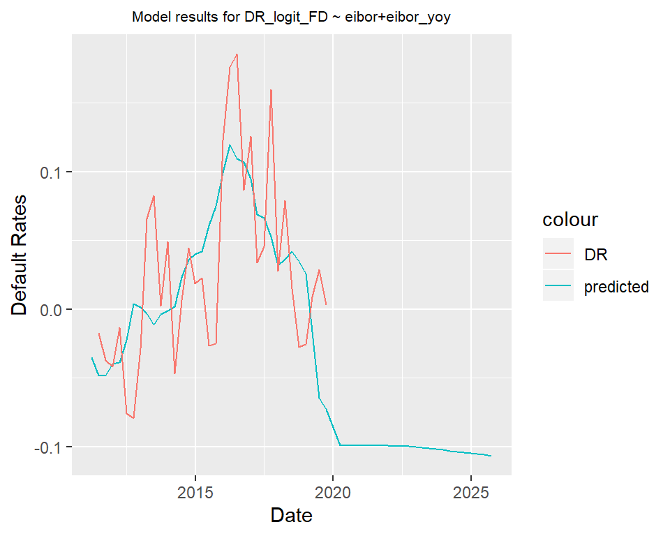

| Date | 31/03/2011 | 30/06/2011 | 30/09/2011 | 31/12/2011 | 31/03/2012 | 30/06/2012 | 30/09/2012 | 31/12/2012 | 31/03/2013 | 30/06/2013 | 30/09/2013 | 31/12/2013 | 31/03/2014 | 30/06/2014 | 30/09/2014 | 31/12/2014 | 31/03/2015 | 30/06/2015 | 30/09/2015 | 31/12/2015 | 31/03/2016 | 30/06/2016 | 30/09/2016 | 31/12/2016 | 31/03/2017 | 30/06/2017 | 30/09/2017 | 31/12/2017 | 31/03/2018 | … |
| --- | --- | --- | --- | --- | --- | --- | --- | --- | --- | --- | --- | --- | --- | --- | --- | --- | --- | --- | --- | --- | --- | --- | --- | --- | --- | --- | --- | --- | --- | --- |
| DR_logit_FD | NA | -0.017286838 | -0.037230734 | -0.041564062 | -0.013549855 | -0.075622008 | -0.079106486 | -0.028395601 | 0.066021917 | 0.082829421 | 0.002488125 | 0.049015182 | -0.047017433 | 0.006364493 | 0.044344414 | 0.018512448 | 0.022610400 | -0.026556347 | -0.024788142 | 0.122798689 | 0.176115301 | 0.185365543 | 0.086454050 | 0.125908108 | 0.033992077 | 0.045653546 | 0.159748619 | 0.027748153 | 0.078890223 | … |
| eibor | 0.021341602 | 0.018679883 | 0.014908871 | 0.014989139 | 0.015345703 | 0.015323828 | 0.013627381 | 0.013009016 | 0.012537500 | 0.009866545 | 0.008714285 | 0.008234203 | 0.008117077 | 0.007439297 | 0.007143789 | 0.006859931 | 0.006892511 | 0.007392292 | 0.007912237 | 0.009024639 | 0.010402552 | 0.010819373 | 0.011776153 | 0.013414903 | 0.014031894 | 0.014817660 | 0.015404073 | 0.016299026 | 0.019565479 | … |
| eibor_yoy | 0.014351624 | -0.190909245 | -0.362905985 | -0.305881348 | -0.280948851 | -0.179661442 | -0.085954867 | -0.132103846 | -0.182996054 | -0.356130516 | -0.360531224 | -0.367038750 | -0.352576078 | -0.246007935 | -0.180220864 | -0.166898070 | -0.150862958 | -0.006318415 | 0.107568663 | 0.315558394 | 0.509254340 | 0.463601950 | 0.488346997 | 0.486475272 | 0.348889516 | 0.369548779 | 0.308073395 | 0.214993942 | 0.394357719 | … |
| predicted_values | -0.035314573 | -0.048285111 | -0.048163155 | -0.039857208 | -0.038518921 | -0.022592741 | 0.004099038 | 0.001325024 | -0.003235074 | -0.011137745 | -0.003603033 | -0.001191468 | 0.001895867 | 0.023323277 | 0.035674184 | 0.039773462 | 0.042037662 | 0.060977498 | 0.075000220 | 0.099448012 | 0.119776228 | 0.109694814 | 0.106722149 | 0.094740360 | 0.068917258 | 0.066528413 | 0.052773589 | 0.031897077 | 0.036521523 | … |

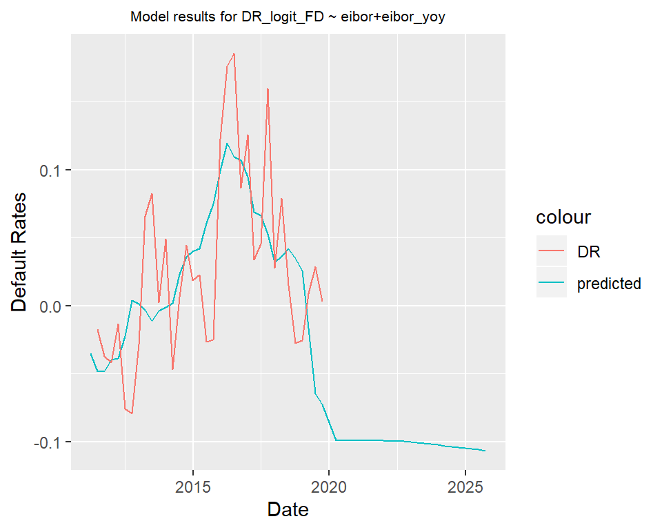

## Challenger Model 3

### Summary Regression Results

Summary Results for `DR_logit_FD ~ DR_logit_FD_lag1 + uae_ann_imp_yoy + rl_est_ad_log + uae_rl_cons_3qma`

| var | Estimates | VIF | p | se | t | DirectionCheck | Significance | Multicollinearity |
| --- | --- | --- | --- | --- | --- | --- | --- | --- |
| (Intercept) | -3.569423 | NA | 0.011275 | 1.304607 | -2.736013 | NA | NA | NA |
| DR_logit_FD_lag1 | 0.120567 | 1.936509 | 0.514672 | 0.182407 | 0.660978 | NA | FAIL | PASS |
| rl_est_ad_log | 0.457886 | 2.972975 | 0.007082 | 0.156095 | 2.933384 | FAIL | PASS | PASS |
| uae_ann_imp_yoy | 0.515797 | 3.651413 | 0.090332 | 0.292770 | 1.761784 | FAIL | FAIL | PASS |
| uae_rl_cons_3qma | -0.006423 | 3.861136 | 0.006889 | 0.002181 | -2.944943 | PASS | PASS | PASS |

| R2 | 0.551369 |
| --- | --- |
| adjR2 | 0.479588 |
| MAPE_test | 4.546684 |

### Diagnostic Tests

Tests for stationarity for `DR_logit_FD ~ DR_logit_FD_lag1 + uae_ann_imp_yoy + rl_est_ad_log + uae_rl_cons_3qma`

| Check | Test | statistic | pvalue | Criteria | results | FINAL |
| --- | --- | --- | --- | --- | --- | --- |
| Heteroskedasticity | Breusch-Pagan Test | 1.885507 | 0.756807 | p > 0.1 | Homoskedasticity | PASS |
| Stationarity-KPSS | KPSS | 0.037801 | 0.1 | p > 0.1 | Stationary | PASS |
| Unit Root | ADF Test | -7.61108 | 0.01 | p < 0.1 | Stationary | PASS |
| Auto-Correlation | Durbin Watson Test | 2.007188 | 0.538 | p > 0.1 | No Auto-Correlation | PASS |
| Normality | Shapiro-Wilk Test | 0.984568 | 0.929614 | p > 0.1 | Residuals Normally distributed | PASS |

### Forecast

Observed versus Predicted Values for `DR_logit_FD ~ DR_logit_FD_lag1 + uae_ann_imp_yoy + rl_est_ad_log + uae_rl_cons_3qma`

[figure not shown]

| Date | 31/03/2011 | 30/06/2011 | 30/09/2011 | 31/12/2011 | 31/03/2012 | 30/06/2012 | 30/09/2012 | 31/12/2012 | 31/03/2013 | 30/06/2013 | 30/09/2013 | 31/12/2013 | 31/03/2014 | 30/06/2014 | 30/09/2014 | 31/12/2014 | 31/03/2015 | 30/06/2015 | 30/09/2015 | 31/12/2015 | 31/03/2016 | 30/06/2016 | 30/09/2016 | 31/12/2016 | 31/03/2017 | 30/06/2017 | 30/09/2017 | 31/12/2017 | 31/03/2018 | … |
| --- | --- | --- | --- | --- | --- | --- | --- | --- | --- | --- | --- | --- | --- | --- | --- | --- | --- | --- | --- | --- | --- | --- | --- | --- | --- | --- | --- | --- | --- | --- |
| DR_logit_FD | NA | -0.017286838 | -0.037230734 | -0.041564062 | -0.013549855 | -0.075622008 | -0.079106486 | -0.028395601 | 0.066021917 | 0.082829421 | 0.002488125 | 0.049015182 | -0.047017433 | 0.006364493 | 0.044344414 | 0.018512448 | 0.022610400 | -0.026556347 | -0.024788142 | 0.122798689 | 0.176115301 | 0.185365543 | 0.086454050 | 0.125908108 | 0.033992077 | 0.045653546 | 0.159748619 | 0.027748153 | 0.078890223 | … |
| DR_logit_FD_lag1 | NA | -0.069312513 | -0.017286838 | -0.037230734 | -0.041564062 | -0.013549855 | -0.075622008 | -0.079106486 | -0.028395601 | 0.066021917 | 0.082829421 | 0.002488125 | 0.049015182 | -0.047017433 | 0.006364493 | 0.044344414 | 0.018512448 | 0.022610400 | -0.026556347 | -0.024788142 | 0.122798689 | 0.176115301 | 0.185365543 | 0.086454050 | 0.125908108 | 0.033992077 | 0.045653546 | 0.159748619 | 0.027748153 | … |
| uae_ann_imp_yoy | 0.187541152 | 0.164149791 | 0.143458377 | 0.124922350 | 0.100098436 | 0.088066612 | 0.080004900 | 0.075530379 | 0.078180393 | 0.078537231 | 0.080416127 | 0.083728407 | 0.122434553 | 0.114351670 | 0.094929611 | 0.064965978 | -0.038318699 | -0.060179383 | -0.067979907 | -0.062106439 | 0.013018517 | 0.027232715 | 0.033733816 | 0.032315937 | 0.003700706 | -0.005177864 | -0.014012293 | -0.022861465 | 0.015000000 | … |
| rl_est_ad_log | 9.366888 | 9.346240 | 9.324383 | 9.305711 | 9.282413 | 9.246286 | 9.212704 | 9.236041 | 9.275066 | 9.319374 | 9.367714 | 9.421087 | 9.499746 | 9.544023 | 9.546932 | 9.546932 | 9.539932 | 9.520371 | 9.518511 | 9.517776 | 9.517457 | 9.505792 | 9.500544 | 9.488805 | 9.455245 | 9.438022 | 9.410838 | 9.390167 | 9.374575 | … |
| uae_rl_cons_3qma | 128.9657 | 127.7480 | 125.9919 | 123.6971 | 119.4108 | 115.1671 | 111.5474 | 110.5859 | 111.3847 | 113.1666 | 115.7097 | 118.2370 | 123.8105 | 128.9203 | 132.5637 | 131.2309 | 123.9742 | 115.6303 | 107.5808 | 104.6624 | 104.9817 | 106.3529 | 108.1514 | 108.1914 | 108.0341 | 107.6797 | 107.1280 | 106.3792 | 107.1018 | … |
| predicted_values | NA | -0.0340995796 | -0.0372279269 | -0.0430044386 | -0.0394683993 | -0.0315822952 | -0.0353523606 | -0.0212199094 | -0.0009999276 | 0.0194105804 | 0.0282065186 | 0.0284350071 | 0.0542287839 | 0.0259358506 | 0.0002850963 | -0.0020307656 | -0.0150163699 | 0.0188370305 | 0.0597341448 | 0.0813846082 | 0.1357311501 | 0.1353429376 | 0.1258571135 | 0.1075684136 | 0.0832089826 | 0.0619374195 | 0.0498826476 | 0.0544189882 | 0.0462526856 | … |

| Date | DR_logit_FD | DR_logit_FD_lag1 | uae_ann_imp_yoy | rl_est_ad_log | uae_rl_cons_3qma | predicted_values |
| --- | --- | --- | --- | --- | --- | --- |
| 31/03/2011 | NA | NA | 0.1875412 | 9.366888 | 128.9657 | NA |
| 30/06/2011 | -0.0172868 | -0.0693125 | 0.1641498 | 9.346240 | 127.7480 | -0.0340996 |
| 30/09/2011 | -0.0372307 | -0.0172868 | 0.1434584 | 9.324383 | 125.9919 | -0.0372279 |
| 31/12/2011 | -0.0415641 | -0.0372307 | 0.1249224 | 9.305711 | 123.6971 | -0.0430044 |
| 31/03/2012 | -0.0135499 | -0.0415641 | 0.1000984 | 9.282413 | 119.4108 | -0.0394684 |
| 30/06/2012 | -0.0756220 | -0.0135499 | 0.0880666 | 9.246287 | 115.1671 | -0.0315823 |
| 30/09/2012 | -0.0791065 | -0.0756220 | 0.0800049 | 9.212704 | 111.5474 | -0.0353524 |
| 31/12/2012 | -0.0283956 | -0.0791065 | 0.0755304 | 9.236041 | 110.5859 | -0.0212199 |
| 31/03/2013 | 0.0660219 | -0.0283956 | 0.0781804 | 9.275066 | 111.3847 | -0.0009999 |
| 30/06/2013 | 0.0828294 | 0.0660219 | 0.0785372 | 9.319374 | 113.1666 | 0.0194106 |
| 30/09/2013 | 0.0024881 | 0.0828294 | 0.0804161 | 9.367714 | 115.7097 | 0.0282065 |
| 31/12/2013 | 0.0490152 | 0.0024881 | 0.0837284 | 9.421087 | 118.2370 | 0.0284350 |
| 31/03/2014 | -0.0470174 | 0.0490152 | 0.1224346 | 9.499746 | 123.8105 | 0.0542288 |
| 30/06/2014 | 0.0063645 | -0.0470174 | 0.1143517 | 9.544023 | 128.9203 | 0.0259359 |
| 30/09/2014 | 0.0443444 | 0.0063645 | 0.0949296 | 9.546932 | 132.5637 | 0.0002851 |
| 31/12/2014 | 0.0185124 | 0.0443444 | 0.0649660 | 9.546932 | 131.2309 | -0.0020308 |
| 31/03/2015 | 0.0226104 | 0.0185124 | -0.0383187 | 9.539932 | 123.9742 | -0.0150164 |
| 30/06/2015 | -0.0265563 | 0.0226104 | -0.0601794 | 9.520371 | 115.6303 | 0.0188370 |
| 30/09/2015 | -0.0247881 | -0.0265563 | -0.0679799 | 9.518511 | 107.5808 | 0.0597341 |
| 31/12/2015 | 0.1227987 | -0.0247881 | -0.0621064 | 9.517776 | 104.6624 | 0.0813846 |
| 31/03/2016 | 0.1761153 | 0.1227987 | 0.0130185 | 9.517457 | 104.9817 | 0.1357312 |
| 30/06/2016 | 0.1853655 | 0.1761153 | 0.0272327 | 9.505792 | 106.3529 | 0.1353429 |
| 30/09/2016 | 0.0864540 | 0.1853655 | 0.0337338 | 9.500544 | 108.1514 | 0.1258571 |
| 31/12/2016 | 0.1259081 | 0.0864540 | 0.0323159 | 9.488805 | 108.1914 | 0.1075684 |
| 31/03/2017 | 0.0339921 | 0.1259081 | 0.0037007 | 9.455245 | 108.0341 | 0.0832090 |
| 30/06/2017 | 0.0456535 | 0.0339921 | -0.0051779 | 9.438022 | 107.6797 | 0.0619374 |
| 30/09/2017 | 0.1597486 | 0.0456535 | -0.0140123 | 9.410838 | 107.1280 | 0.0498826 |
| 31/12/2017 | 0.0277482 | 0.1597486 | -0.0228615 | 9.390167 | 106.3792 | 0.0544190 |
| 31/03/2018 | 0.0788902 | 0.0277482 | 0.0150000 | 9.374575 | 107.1018 | 0.0462527 |
| 30/06/2018 | 0.0153226 | 0.0462527 | 0.0294482 | 9.366080 | 108.4221 | 0.0435663 |
| 30/09/2018 | -0.0275671 | 0.0435663 | 0.0455467 | 9.348040 | 110.3744 | 0.0307467 |
| 31/12/2018 | -0.0256946 | 0.0307467 | 0.0625446 | 9.324170 | 111.2942 | 0.0211303 |
| 31/03/2019 | 0.0092233 | 0.0211303 | 0.0315353 | 9.300901 | 112.0893 | -0.0117844 |
| 30/06/2019 | 0.0290099 | -0.0117844 | 0.0306242 | 9.289334 | 112.8928 | -0.0266797 |
| 30/09/2019 | 0.0027851 | -0.0266797 | 0.0299570 | 9.283131 | 113.7423 | -0.0371163 |
| 31/12/2019 | NA | -0.0371163 | 0.0281534 | 9.277064 | 114.5641 | -0.0473613 |
| 31/03/2020 | NA | -0.0473613 | 0.0274089 | 9.278314 | 115.2627 | -0.0528953 |
| 30/06/2020 | NA | -0.0528953 | 0.0269356 | 9.279563 | 115.9765 | -0.0578194 |
| 30/09/2020 | NA | -0.0578194 | 0.0267919 | 9.280812 | 116.7991 | -0.0631981 |
| 31/12/2020 | NA | -0.0631981 | 0.0269398 | 9.282061 | 117.6268 | -0.0685149 |
| 31/03/2021 | NA | -0.0685149 | 0.0273623 | 9.285804 | 118.3623 | -0.0719476 |
| 30/06/2021 | NA | -0.0719476 | 0.0276441 | 9.289547 | 119.1301 | -0.0754341 |
| 30/09/2021 | NA | -0.0754341 | 0.0280104 | 9.293290 | 120.0188 | -0.0796592 |
| 31/12/2021 | NA | -0.0796592 | 0.0284328 | 9.297033 | 120.9135 | -0.0839839 |
| 31/03/2022 | NA | -0.0839839 | 0.0297872 | 9.300878 | 121.7559 | -0.0874566 |
| 30/06/2022 | NA | -0.0874566 | 0.0283022 | 9.304825 | 122.5563 | -0.0919748 |
| 30/09/2022 | NA | -0.0919748 | 0.0270558 | 9.308874 | 123.4140 | -0.0968171 |
| 31/12/2022 | NA | -0.0968171 | 0.0283333 | 9.313024 | 124.2765 | -0.1003812 |
| 31/03/2023 | NA | -0.1003812 | 0.0282935 | 9.317277 | 125.1439 | -0.1044553 |
| 30/06/2023 | NA | -0.1044553 | 0.0282537 | 9.321632 | 126.0162 | -0.1085757 |
| 30/09/2023 | NA | -0.1085757 | 0.0282139 | 9.326088 | 126.8934 | -0.1126867 |
| 31/12/2023 | NA | -0.1126867 | 0.0281741 | 9.330646 | 127.7755 | -0.1167815 |
| 31/03/2024 | NA | -0.1167815 | 0.0281343 | 9.335306 | 128.6626 | -0.1208597 |
| 30/06/2024 | NA | -0.1208597 | 0.0280945 | 9.340067 | 129.5546 | -0.1249212 |
| 30/09/2024 | NA | -0.1249212 | 0.0280547 | 9.344930 | 130.4516 | -0.1289662 |
| 31/12/2024 | NA | -0.1289662 | 0.0280149 | 9.349894 | 131.3537 | -0.1329947 |
| 31/03/2025 | NA | -0.1329947 | 0.0279751 | 9.354960 | 132.2607 | -0.1370071 |
| 30/06/2025 | NA | -0.1370071 | 0.0279353 | 9.360128 | 133.1728 | -0.1410034 |
| 30/09/2025 | NA | -0.1410034 | 0.0278955 | 9.365397 | 134.0899 | -0.1449837 |

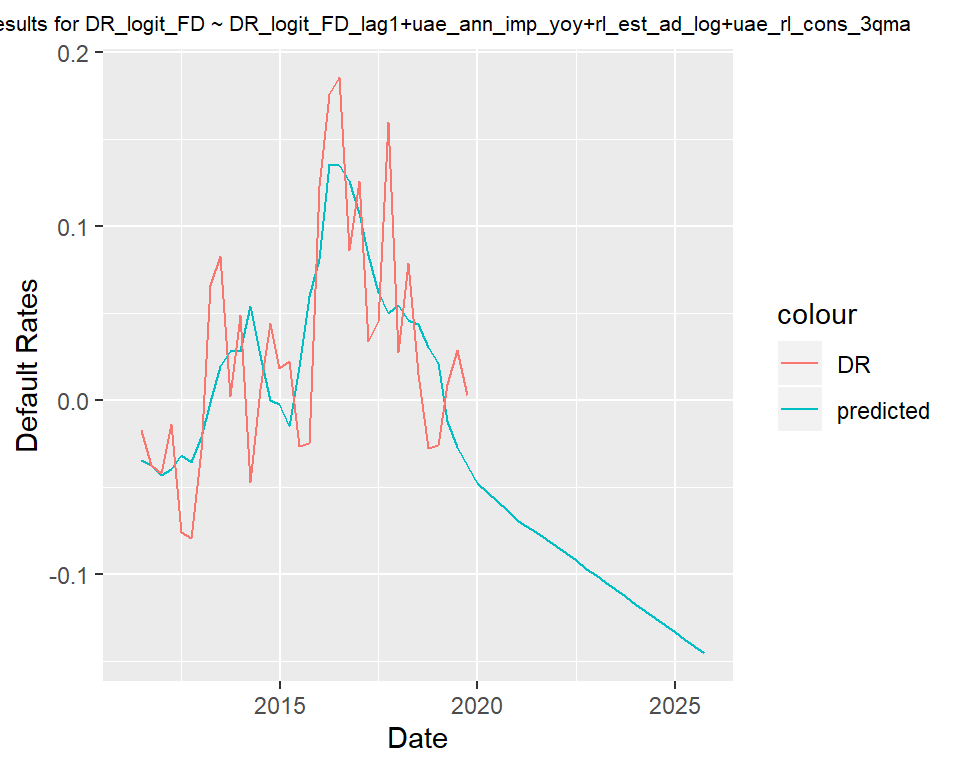

## Challenger Model 4

### Summary Regression Results

Summary Results for `DR_logit_FD ~ uae_rl_cons+rl_est_ad_yoy.1`

| var | Estimates | VIF | p | se | t | DirectionCheck | Significance | Multicollinearity |
| --- | --- | --- | --- | --- | --- | --- | --- | --- |
| (Intercept) | 0.661418 | NA | 0.005278 | 0.217960 | 3.034592 | NA | NA | NA |
| rl_est_ad_yoy.1 | 0.318425 | 2.008192 | 0.049516 | 0.154838 | 2.056510 | NA | PASS | PASS |
| uae_rl_cons | -0.005526 | 2.008192 | 0.007395 | 0.001908 | -2.896397 | PASS | PASS | PASS |

| R2 | 0.237054 |
| --- | --- |
| adjR2 | 0.180540 |
| MAPE_test | 1.250057 |

### Diagnostic Tests

Tests for stationarity for `DR_logit_FD ~ uae_rl_cons+rl_est_ad_yoy.1`

| Check | Test | statistic | pvalue | Criteria | results | FINAL |
| --- | --- | --- | --- | --- | --- | --- |
| Heteroskedasticity | Breusch-Pagan Test | 4.36699 | 0.112647 | p > 0.1 | Homoskedasticity | PASS |
| Stationarity-KPSS | KPSS | 0.228637 | 0.1 | p > 0.1 | Stationary | PASS |
| Unit Root | ADF Test | -4.210308 | 0.014778 | p < 0.1 | Stationary | PASS |
| Auto-Correlation | Durbin Watson Test | 1.157192 | 0.006 | p > 0.1 | Auto-Correlation | FAIL |
| Normality | Shapiro-Wilk Test | 0.965108 | 0.41527 | p > 0.1 | Residuals Normally distributed | PASS |

### Forecast

Observed versus Predicted Values for `DR_logit_FD ~ uae_rl_cons+rl_est_ad_yoy.1`

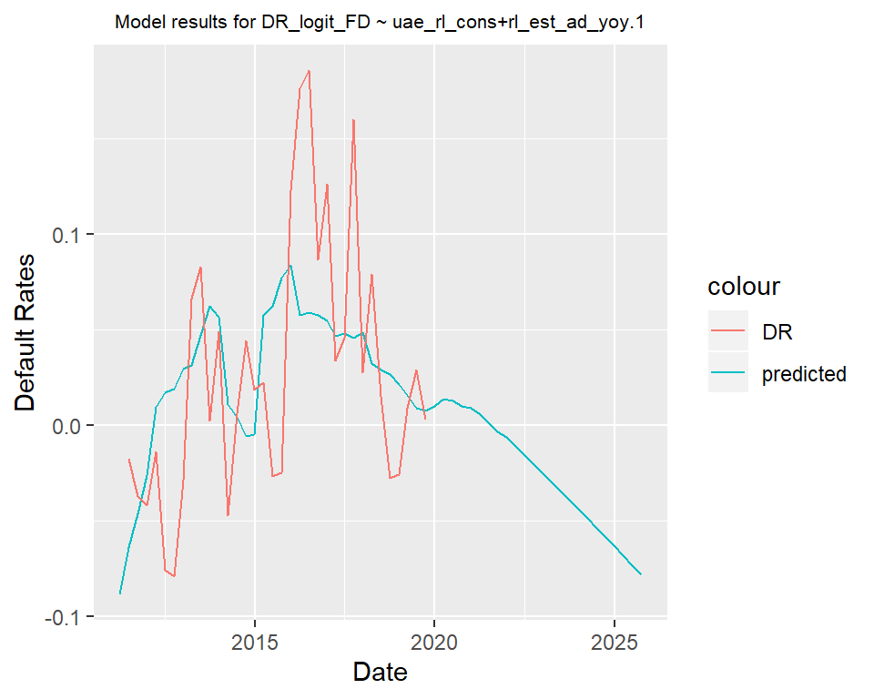

| Date | 31/03/2011 | 30/06/2011 | 30/09/2011 | 31/12/2011 | 31/03/2012 | 30/06/2012 | 30/09/2012 | 31/12/2012 | 31/03/2013 | 30/06/2013 | 30/09/2013 | 31/12/2013 | 31/03/2014 | 30/06/2014 | 30/09/2014 | 31/12/2014 | 31/03/2015 | 30/06/2015 | 30/09/2015 | 31/12/2015 | 31/03/2016 | 30/06/2016 | 30/09/2016 | 31/12/2016 | 31/03/2017 | 30/06/2017 | 30/09/2017 | 31/12/2017 | 31/03/2018 | … |
| --- | --- | --- | --- | --- | --- | --- | --- | --- | --- | --- | --- | --- | --- | --- | --- | --- | --- | --- | --- | --- | --- | --- | --- | --- | --- | --- | --- | --- | --- | --- |
| DR_logit_FD | NA | -0.017286838 | -0.037230734 | -0.041564062 | -0.013549855 | -0.075622008 | -0.079106486 | -0.028395601 | 0.066021917 | 0.082829421 | 0.002488125 | 0.049015182 | -0.047017433 | 0.006364493 | 0.044344414 | 0.018512448 | 0.022610400 | -0.026556347 | -0.024788142 | 0.122798689 | 0.176115301 | 0.185365543 | 0.086454050 | 0.125908108 | 0.033992077 | 0.045653546 | 0.159748619 | 0.027748153 | 0.078890223 | … |
| uae_rl_cons | 127.9276 | 126.1714 | 123.8767 | 121.0434 | 113.3123 | 111.1456 | 110.1842 | 110.4279 | 113.5419 | 115.5300 | 118.0573 | 121.1238 | 132.2503 | 133.3867 | 132.0540 | 128.2520 | 111.6168 | 107.0220 | 104.1036 | 102.8616 | 107.9799 | 108.2171 | 108.2571 | 108.0999 | 107.7454 | 107.1938 | 106.4449 | 105.4989 | 109.3616 | … |
| rl_est_ad_yoy.1 | -0.134305525 | -0.086858327 | -0.072159828 | -0.058779910 | -0.081005587 | -0.095120319 | -0.105668570 | -0.067298952 | -0.007319645 | 0.075824812 | 0.167669848 | 0.203274747 | 0.251921515 | 0.251883070 | 0.196280580 | 0.134105513 | 0.041004268 | -0.023374639 | -0.028020474 | -0.028734674 | -0.022223820 | -0.014472912 | -0.017806407 | -0.028555321 | -0.060316293 | -0.065525017 | -0.085800314 | -0.093929590 | -0.077501963 | … |
| predicted_values | -0.088229619 | -0.063417265 | -0.046057101 | -0.026140990 | 0.009501349 | 0.016978856 | 0.018932587 | 0.029803561 | 0.031695760 | 0.047185463 | 0.062466378 | 0.056859751 | 0.010868711 | 0.004577009 | -0.005763747 | -0.004553448 | 0.057720771 | 0.062610110 | 0.077256825 | 0.083892339 | 0.057683341 | 0.058840898 | 0.057558577 | 0.055004673 | 0.046849677 | 0.048239257 | 0.045920936 | 0.048559886 | 0.032446891 | … |

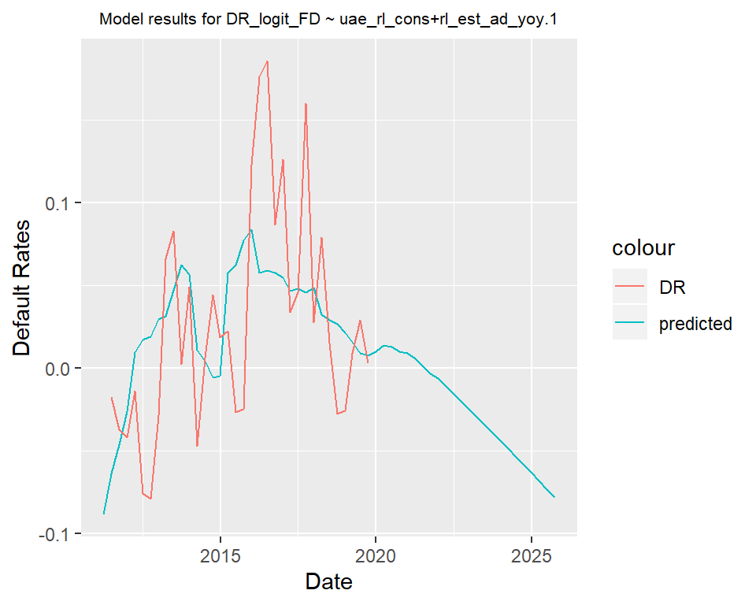

## Data and Assumptions

### Training Data Used

| Date | DR_logit_FD | avg_oil_pri_barr | rl_est_ad_yoy | uae_rl_cons | eibor | eibor_yoy | DR_logit_FD_lag1 | uae_ann_imp_yoy | rl_est_ad_log | uae_rl_cons_3qma | rl_est_ad_yoy.1 |
| --- | --- | --- | --- | --- | --- | --- | --- | --- | --- | --- | --- |
| 31/03/2011 | NA | 104.96000 | -0.1343055 | 127.9276 | 0.0213416 | 0.0143516 | NA | 0.1875412 | 9.366888 | 128.9657 | -0.1343055 |
| 30/06/2011 | -0.0172868 | 117.36000 | -0.0868583 | 126.1714 | 0.0186799 | -0.1909092 | -0.0693125 | 0.1641498 | 9.346240 | 127.7480 | -0.0868583 |
| 30/09/2011 | -0.0372307 | 113.34000 | -0.0721598 | 123.8767 | 0.0149089 | -0.3629060 | -0.0172868 | 0.1434584 | 9.324383 | 125.9919 | -0.0721598 |
| 31/12/2011 | -0.0415641 | 109.39667 | -0.0587799 | 121.0434 | 0.0149891 | -0.3058813 | -0.0372307 | 0.1249224 | 9.305711 | 123.6971 | -0.0587799 |
| 31/03/2012 | -0.0135499 | 118.49000 | -0.0810056 | 113.3123 | 0.0153457 | -0.2809489 | -0.0415641 | 0.1000984 | 9.282413 | 119.4108 | -0.0810056 |
| 30/06/2012 | -0.0756220 | 108.41667 | -0.0951203 | 111.1456 | 0.0153238 | -0.1796614 | -0.0135499 | 0.0880666 | 9.246287 | 115.1671 | -0.0951203 |
| 30/09/2012 | -0.0791065 | 109.61333 | -0.1056686 | 110.1842 | 0.0136274 | -0.0859549 | -0.0756220 | 0.0800049 | 9.212704 | 111.5474 | -0.1056686 |
| 31/12/2012 | -0.0283956 | 110.08667 | -0.0672990 | 110.4279 | 0.0130090 | -0.1321038 | -0.0791065 | 0.0755304 | 9.236041 | 110.5859 | -0.0672990 |
| 31/03/2013 | 0.0660219 | 112.49333 | -0.0073196 | 113.5419 | 0.0125375 | -0.1829961 | -0.0283956 | 0.0781804 | 9.275066 | 111.3847 | -0.0073196 |
| 30/06/2013 | 0.0828294 | 102.57667 | 0.0758248 | 115.5300 | 0.0098665 | -0.3561305 | 0.0660219 | 0.0785372 | 9.319374 | 113.1666 | 0.0758248 |
| 30/09/2013 | 0.0024881 | 110.27000 | 0.1676698 | 118.0573 | 0.0087143 | -0.3605312 | 0.0828294 | 0.0804161 | 9.367714 | 115.7097 | 0.1676698 |
| 31/12/2013 | 0.0490152 | 109.21000 | 0.2032747 | 121.1238 | 0.0082342 | -0.3670388 | 0.0024881 | 0.0837284 | 9.421087 | 118.2370 | 0.2032747 |
| 31/03/2014 | -0.0470174 | 108.16667 | 0.2519215 | 132.2503 | 0.0081171 | -0.3525761 | 0.0490152 | 0.1224346 | 9.499746 | 123.8105 | 0.2519215 |
| 30/06/2014 | 0.0063645 | 109.70000 | 0.2518831 | 133.3867 | 0.0074393 | -0.2460079 | -0.0470174 | 0.1143517 | 9.544023 | 128.9203 | 0.2518831 |
| 30/09/2014 | 0.0443444 | 101.82333 | 0.1962806 | 132.0540 | 0.0071438 | -0.1802209 | 0.0063645 | 0.0949296 | 9.546932 | 132.5637 | 0.1962806 |
| 31/12/2014 | 0.0185124 | 76.40333 | 0.1341055 | 128.2520 | 0.0068599 | -0.1668981 | 0.0443444 | 0.0649660 | 9.546932 | 131.2309 | 0.1341055 |
| 31/03/2015 | 0.0226104 | 53.91667 | 0.0410043 | 111.6168 | 0.0068925 | -0.1508630 | 0.0185124 | -0.0383187 | 9.539932 | 123.9742 | 0.0410043 |
| 30/06/2015 | -0.0265563 | 61.69333 | -0.0233746 | 107.0220 | 0.0073923 | -0.0063184 | 0.0226104 | -0.0601794 | 9.520371 | 115.6303 | -0.0233746 |
| 30/09/2015 | -0.0247881 | 50.23333 | -0.0280205 | 104.1036 | 0.0079122 | 0.1075687 | -0.0265563 | -0.0679799 | 9.518511 | 107.5808 | -0.0280205 |
| 31/12/2015 | 0.1227987 | 43.57000 | -0.0287347 | 102.8616 | 0.0090246 | 0.3155584 | -0.0247881 | -0.0621064 | 9.517776 | 104.6624 | -0.0287347 |
| 31/03/2016 | 0.1761153 | 33.69667 | -0.0222238 | 107.9799 | 0.0104026 | 0.5092543 | 0.1227987 | 0.0130185 | 9.517457 | 104.9817 | -0.0222238 |
| 30/06/2016 | 0.1853655 | 45.52333 | -0.0144729 | 108.2171 | 0.0108194 | 0.4636020 | 0.1761153 | 0.0272327 | 9.505792 | 106.3529 | -0.0144729 |
| 30/09/2016 | 0.0864540 | 45.78667 | -0.0178064 | 108.2571 | 0.0117762 | 0.4883470 | 0.1853655 | 0.0337338 | 9.500544 | 108.1514 | -0.0178064 |
| 31/12/2016 | 0.1259081 | 49.18667 | -0.0285553 | 108.0999 | 0.0134149 | 0.4864753 | 0.0864540 | 0.0323159 | 9.488805 | 108.1914 | -0.0285553 |
| 31/03/2017 | 0.0339921 | 53.68000 | -0.0603163 | 107.7454 | 0.0140319 | 0.3488895 | 0.1259081 | 0.0037007 | 9.455245 | 108.0341 | -0.0603163 |
| 30/06/2017 | 0.0456535 | 49.67000 | -0.0655250 | 107.1938 | 0.0148177 | 0.3695488 | 0.0339921 | -0.0051779 | 9.438022 | 107.6797 | -0.0655250 |
| 30/09/2017 | 0.1597486 | 52.11000 | -0.0858003 | 106.4449 | 0.0154041 | 0.3080734 | 0.0456535 | -0.0140123 | 9.410838 | 107.1280 | -0.0858003 |
| 31/12/2017 | 0.0277482 | 61.53000 | -0.0939296 | 105.4989 | 0.0162990 | 0.2149939 | 0.1597486 | -0.0228615 | 9.390167 | 106.3792 | -0.0939296 |
| 31/03/2018 | 0.0788902 | 66.80667 | -0.0775020 | 109.3616 | 0.0195655 | 0.3943577 | 0.0277482 | 0.0150000 | 9.374575 | 107.1018 | -0.0775020 |
| 30/06/2018 | 0.0153226 | 74.50000 | -0.0694146 | 110.4058 | 0.0245555 | 0.6571806 | 0.0788902 | 0.0294482 | 9.366080 | 108.4221 | -0.0694146 |
| 30/09/2018 | -0.0275671 | 75.22333 | -0.0608667 | 111.3557 | 0.0255949 | 0.6615653 | 0.0153226 | 0.0455467 | 9.348040 | 110.3744 | -0.0608667 |

### Test Data Used

| Date | DR_logit_FD | avg_oil_pri_barr | rl_est_ad_yoy | uae_rl_cons | eibor | eibor_yoy | DR_logit_FD_lag1 | uae_ann_imp_yoy | rl_est_ad_log | uae_rl_cons_3qma | rl_est_ad_yoy.1 |
| --- | --- | --- | --- | --- | --- | --- | --- | --- | --- | --- | --- |
| 31/12/2018 | -0.0256946 | 67.71333 | -0.0638665 | 112.1213 | 0.0276219 | 0.6946965 | -0.0275671 | 0.0625446 | 9.324170 | 111.2942 | -0.0638665 |
| 31/03/2019 | 0.0092233 | 61.69023 | -0.0710259 | 112.7910 | 0.0300000 | 0.5333128 | -0.0256946 | 0.0315353 | 9.300901 | 112.0893 | -0.0710259 |
| 30/06/2019 | 0.0290099 | 66.27000 | -0.0738749 | 113.7662 | 0.0300000 | 0.2217204 | 0.0092233 | 0.0306242 | 9.289334 | 112.8928 | -0.0738749 |
| 30/09/2019 | 0.0027851 | 66.05667 | -0.0628473 | 114.6698 | 0.0300000 | 0.1721097 | 0.0290099 | 0.0299570 | 9.283131 | 113.7423 | -0.0628473 |

### Variable plots

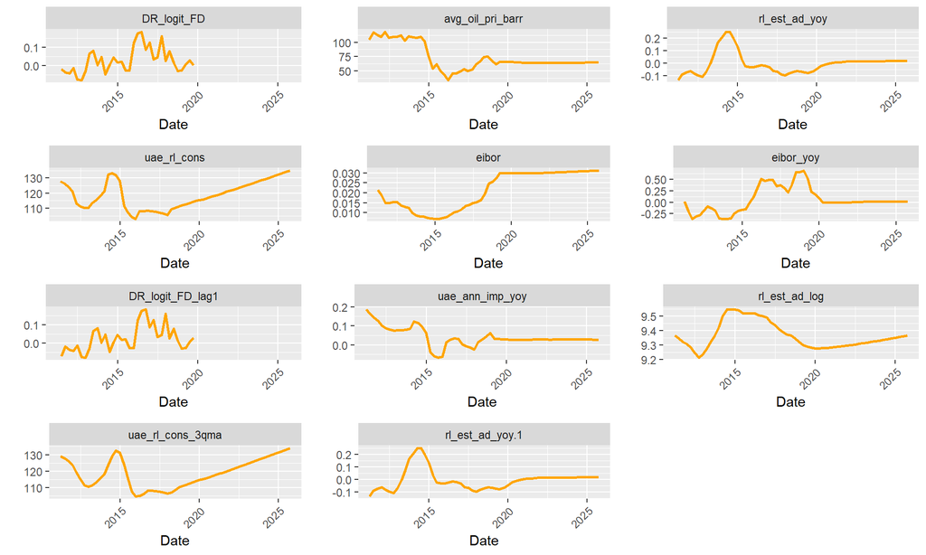

```
## ##------ Fri Sep 06 17:29:23 2019 ------##
```

A work by [Aptivaa](https://www.aptivaa.com)

*info@aptivaa.com*